# YOUTUBE DATA COLLECTION & ANALYSIS

# Observation:

- We have droped that video details.

```python
# Grouping data based on duration category

duration_matrix = trending_videos.groupby('duration_category')[['view_count','like_count','comment_count']].sum()
duration_matrix
```

| duration_category | view_count | like_count | comment_count |
| --- | --- | --- | --- |
| 0-1 min | 17618724 | 300609 | 5834 |
| 1-5 min | 129413291 | 3504140 | 388127 |
| 5-10 min | 24364253 | 617241 | 34304 |
| 10-20 min | 22082276 | 1005185 | 42323 |
| 20-60 min | 102627742 | 2999108 | 118184 |
| 60-120 min | 0 | 0 | 0 |
| >120 min | 0 | 0 | 0 |

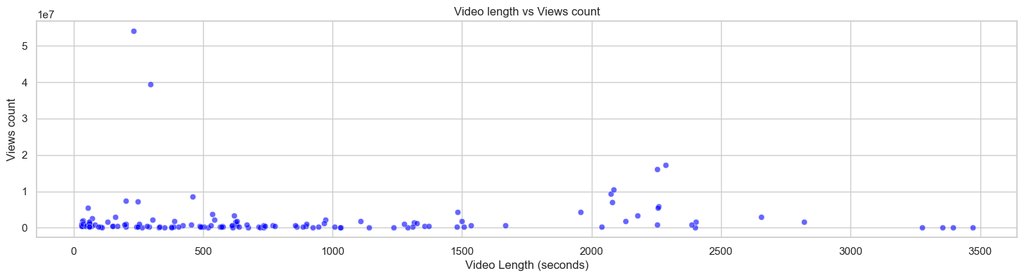

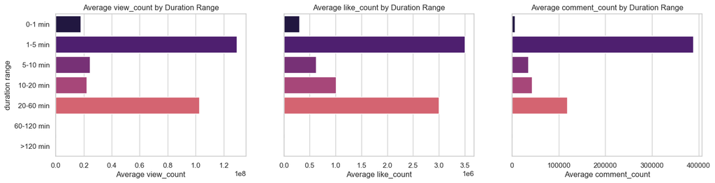

```python
# View according the duration
plt.figure(figsize = (18,4))
sns.scatterplot(x = 'duration_seconds', y = 'view_count', data = trending_videos, alpha = 0.6, color = 'blue')
plt.title("Video length vs Views count")
plt.xlabel("Video Length (seconds)")
plt.ylabel("Views count")
plt.show()

def duration_analysis(y, x, ax):
    sns.barplot(y=y, x=x, data=duration_matrix.reset_index(), ax=ax, palette='magma')
    ax.set_title(f"Average {x} by Duration Range")
    ax.set_xlabel(f"Average {x}")
    if ax == axes[0]:
        ax.set_ylabel("duration range")
    else:
        ax.set_ylabel("")
        ax.set_yticks([])

# Setting up the figure and axes
fig, axes = plt.subplots(nrows=1, ncols=3, figsize=(18, 4))

# Plotting the averages
duration_analysis(y='duration_category', x='view_count', ax=axes[0])
duration_analysis(y='duration_category', x='like_count', ax=axes[1])
duration_analysis(y='duration_category', x='comment_count', ax=axes[2])

plt.show()
```

## Observations:

- For videos with duration 1-5 mins have good reach, hight view counts, like counts and comment counts.
- For short videos with duration 0-1 mins are getting very less comments when compared with it's views and likes.
- Videos with duration 20-60 mins are getting high views count and likes count after for the videos 1-5 min but getting less number of comments coaparatively.

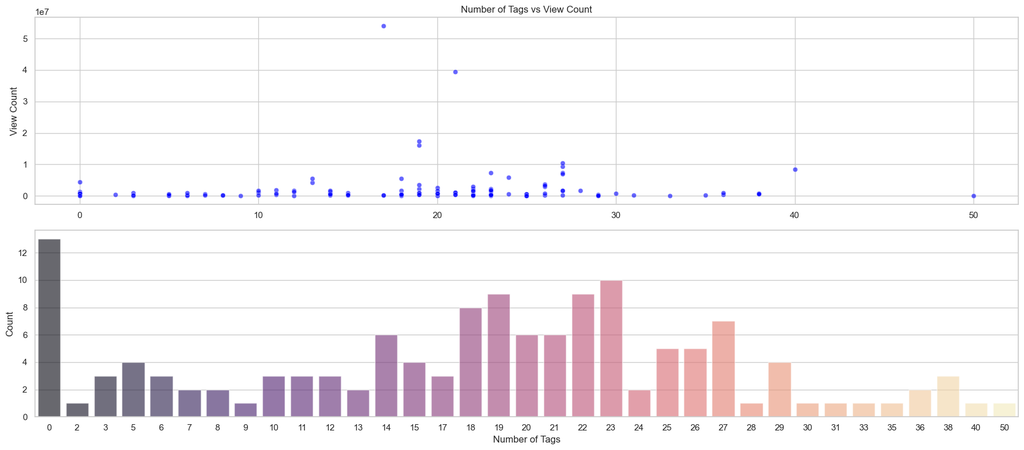

```python
# Relation between number of tags and views
trending_videos['tags_count'] = trending_videos['tags'].apply(len)


fig, axes = plt.subplots(nrows=2, ncols=1, figsize=(18, 8))
# Scatter plot for Number of tags vs View count
sns.scatterplot(x='tags_count', y='view_count', data=trending_videos, ax=axes[0], alpha=0.6, color='blue')
axes[0].set_title("Number of Tags vs View Count")
axes[0].set_xlabel("")
axes[0].set_ylabel("View Count")

# bar graph for Number of tags vs View count
sns.countplot(x='tags_count', data=trending_videos, ax=axes[1], alpha=0.6, palette='magma')
axes[1].set_xlabel("Number of Tags")
axes[1].set_ylabel("Count")

plt.tight_layout()
plt.show()
```